The study that we’re going to do corresponds to the “One Way Analysis of Variance (ANOVA)”. We’re actually trying to see if the dose of a sweetener increases the weights of piglets i.e. makes them fat. In this regard, one experiment was performed. A set of piglets with similar conditions where selected and 5 different sweetener doses where considered and randomly assigned to the piglets. The response variable is the mean weight gained per day, GMD, and the explanatory variable is the sweetener dose. Here, as you can guess, the sweetner dose is a **categorical variable**.

```r
dd<-read.csv2("GMD.csv")
library(car)
library(lsmeans)
library(tables)
library("RcmdrMisc")
library("multcompView")
```

View(dd)

We can check if the categorical variable is a factor or not. In case, it is not a factor which is a pre-requisite condition for performing the ANOVA test, we can actually convert it into a factir variable and proceed. The following code accomplishes this task.

```r
if(is.factor(dd$DOSI)==F){
  dd$DOSI<-as.factor(dd$DOSI)
}else{
  cat("The variable is a factor. You can proceed with the analysis")
}
```

Creating a table of the mean and standard deviation with respect to the categorical variable “DOSI” that corresponds to the different dosage of the sweetner.

```r
tabular(DOSI~Y*((n=1)+mean+sd),dd)
```

```
##
##       Y
##  DOSI n mean  sd
##  0    5 196.3  5.385
##  8    5 200.2 11.335
##  15   5 224.2  7.563
##  20   5 231.1  9.584
##  30   5 231.0  9.727
```

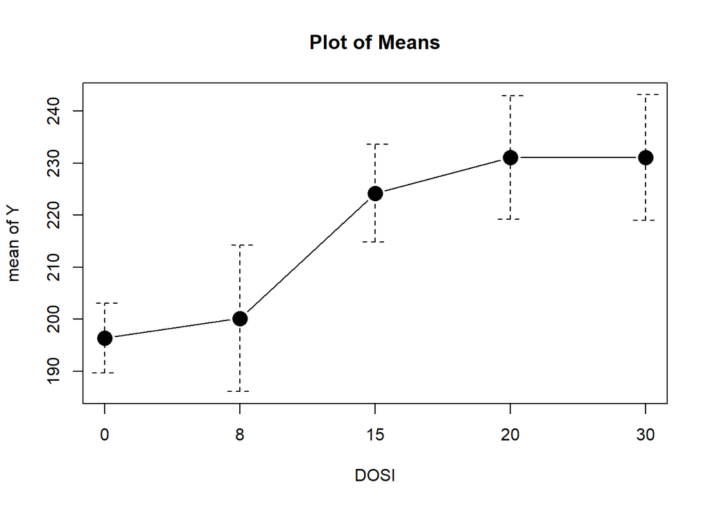

```r
with(dd, plotMeans(Y, DOSI, error.bars="conf.int",level=0.95, connect=TRUE))
```

```r
mod<-lm(Y~DOSI,dd)

summary(mod)
```

```
##
## Call:
## lm(formula = Y ~ DOSI, data = dd)
##
## Residuals:
##      Min       1Q   Median       3Q      Max
## -15.1500  -6.7333  -0.4833   8.1333  11.5167
##
## Coefficients:
##             Estimate Std. Error t value Pr(>|t|)
## (Intercept)  196.350      4.006  49.017  < 2e-16 ***
## DOSI8          3.800      5.665   0.671     0.51
## DOSI15        27.850      5.665   4.916 8.34e-05 ***
## DOSI20        34.717      5.665   6.128 5.47e-06 ***
## DOSI30        34.683      5.665   6.122 5.54e-06 ***
## ---
## Signif. codes:  0 '***' 0.001 '**' 0.01 '*' 0.05 '.' 0.1 ' ' 1
##
## Residual standard error: 8.957 on 20 degrees of freedom
## Multiple R-squared:  0.7827, Adjusted R-squared:  0.7393
## F-statistic: 18.01 on 4 and 20 DF,  p-value: 2.071e-06
```

```r
anova(mod)
```

```
## Analysis of Variance Table
##
## Response: Y
##           Df Sum Sq Mean Sq F value    Pr(>F)
## DOSI       4 5780.1 1445.03  18.011 2.071e-06 ***
## Residuals 20 1604.6   80.23
## ---
## Signif. codes:  0 '***' 0.001 '**' 0.01 '*' 0.05 '.' 0.1 ' ' 1
```

```r
Anova(mod,ty=3)
```

```
## Anova Table (Type III tests)
##
## Response: Y
##             Sum Sq Df  F value    Pr(>F)
## (Intercept) 192767  1 2402.629 < 2.2e-16 ***
## DOSI          5780  4   18.011 2.071e-06 ***
## Residuals     1605 20
## ---
## Signif. codes:  0 '***' 0.001 '**' 0.01 '*' 0.05 '.' 0.1 ' ' 1
```

```r
lsm<-lsmeans(mod,~DOSI)
lsm
```

```
##  DOSI   lsmean       SE df lower.CL upper.CL
##  0    196.3500 4.005784 20 187.9941 204.7059
##  8    200.1500 4.005784 20 191.7941 208.5059
##  15   224.2000 4.005784 20 215.8441 232.5559
##  20   231.0667 4.005784 20 222.7107 239.4226
##  30   231.0333 4.005784 20 222.6774 239.3893
##
## Confidence level used: 0.95
```

```r
pairs(lsm)
```

```
##  contrast   estimate       SE df t.ratio p.value
##  0 - 8     -3.800000 5.665034 20  -0.671  0.9605
##  0 - 15   -27.850000 5.665034 20  -4.916  0.0007
##  0 - 20   -34.716666 5.665034 20  -6.128  <.0001
##  0 - 30   -34.683333 5.665034 20  -6.122  <.0001
##  8 - 15   -24.050000 5.665034 20  -4.245  0.0032
##  8 - 20   -30.916666 5.665034 20  -5.457  0.0002
##  8 - 30   -30.883333 5.665034 20  -5.452  0.0002
##  15 - 20   -6.866667 5.665034 20  -1.212  0.7446
##  15 - 30   -6.833334 5.665034 20  -1.206  0.7479
##  20 - 30    0.033333 5.665034 20   0.006  1.0000
##
## P value adjustment: tukey method for comparing a family of 5 estimates
```

```r
cld(lsm,alpha=0.01)
```

```
##  DOSI   lsmean       SE df lower.CL upper.CL .group
##  0    196.3500 4.005784 20 187.9941 204.7059  1
##  8    200.1500 4.005784 20 191.7941 208.5059  1
##  15   224.2000 4.005784 20 215.8441 232.5559   2
##  30   231.0333 4.005784 20 222.6774 239.3893   2
##  20   231.0667 4.005784 20 222.7107 239.4226   2
##
## Confidence level used: 0.95
## P value adjustment: tukey method for comparing a family of 5 estimates
## significance level used: alpha = 0.01
```

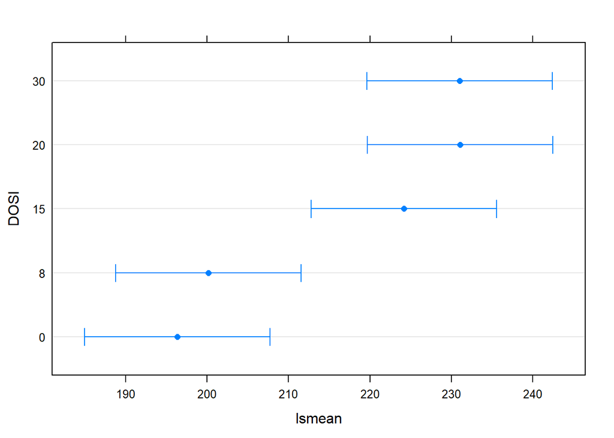

```r
plot(lsm,level=0.99)
```

```r
confint(lsm,level=0.99)
```

```
##  DOSI   lsmean       SE df lower.CL upper.CL
##  0    196.3500 4.005784 20 184.9522 207.7478
##  8    200.1500 4.005784 20 188.7522 211.5478
##  15   224.2000 4.005784 20 212.8022 235.5978
##  20   231.0667 4.005784 20 219.6689 242.4645
##  30   231.0333 4.005784 20 219.6355 242.4311
##
## Confidence level used: 0.99
```

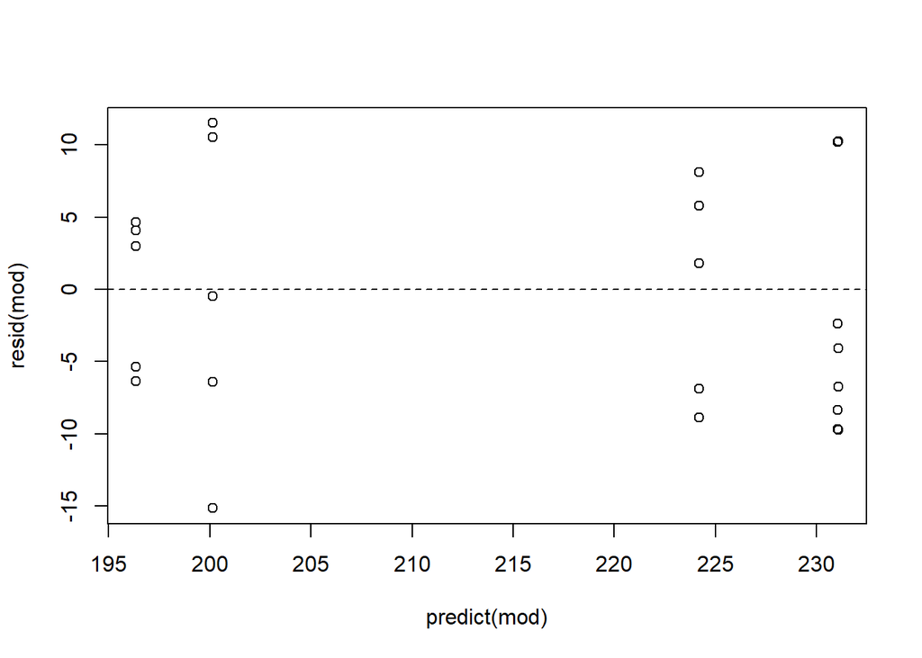

```r
plot(predict(mod),resid(mod))
abline(h=0,lty=2)
```

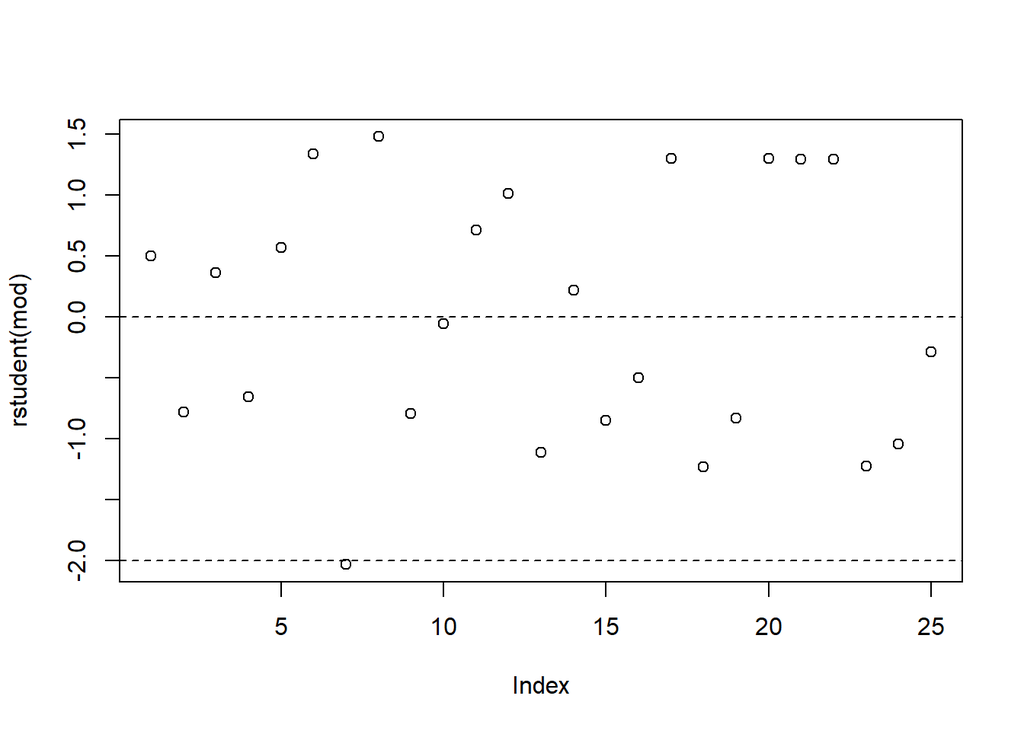

```r
plot(rstudent(mod))
abline(h=c(-2,0,2),lty=2)
```

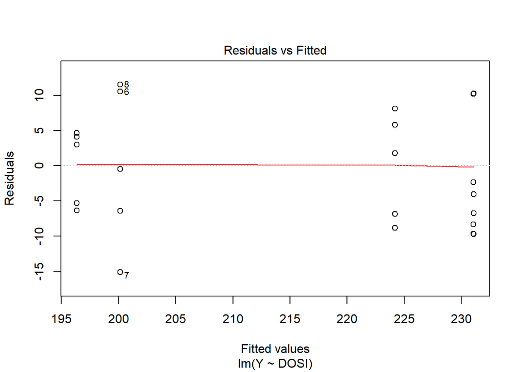

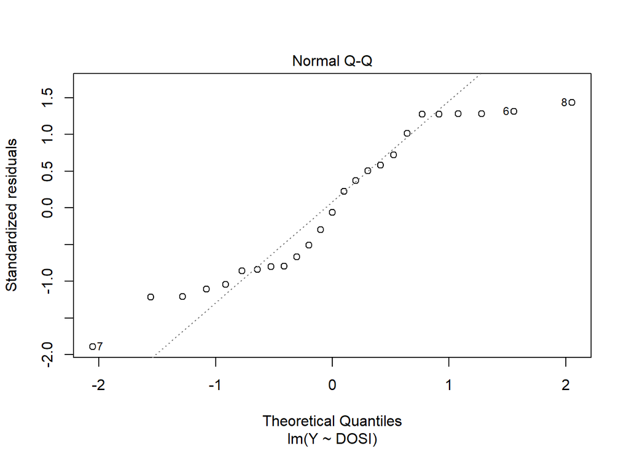

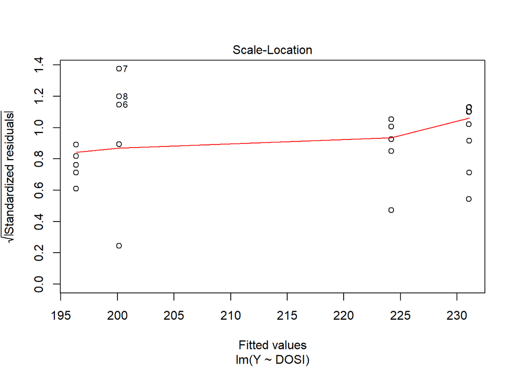

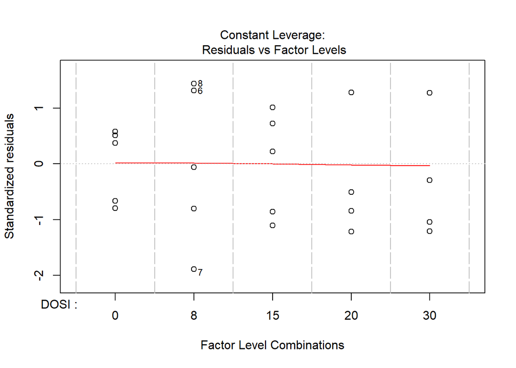

```r
plot(mod,ask=F)
```

```r
predict(mod)
```

```
##        1        2        3        4        5        6        7        8
## 196.3500 196.3500 196.3500 196.3500 196.3500 200.1500 200.1500 200.1500
##        9       10       11       12       13       14       15       16
## 200.1500 200.1500 224.2000 224.2000 224.2000 224.2000 224.2000 231.0667
##       17       18       19       20       21       22       23       24
## 231.0667 231.0667 231.0667 231.0667 231.0333 231.0333 231.0333 231.0333
##       25
## 231.0333
```

```r
resid(mod)
```

```
##           1           2           3           4           5           6
##   4.0666670  -6.3500000   2.9833330  -5.3500000   4.6500000  10.5166668
##           7           8           9          10          11          12
## -15.1500002  11.5166668  -6.4000002  -0.4833332   5.8000002   8.1333332
##          13          14          15          16          17          18
##  -8.8666668   1.8000002  -6.8666668  -4.0666664  10.2666666  -9.7333334
##          19          20          21          22          23          24
##  -6.7333334  10.2666666  10.2166666  10.2166666  -9.7000004  -8.3666664
##          25
##  -2.3666664
```

```r
hatvalues(mod)
```

```
##   1   2   3   4   5   6   7   8   9  10  11  12  13  14  15  16  17  18
## 0.2 0.2 0.2 0.2 0.2 0.2 0.2 0.2 0.2 0.2 0.2 0.2 0.2 0.2 0.2 0.2 0.2 0.2
##  19  20  21  22  23  24  25
## 0.2 0.2 0.2 0.2 0.2 0.2 0.2
```

```r
dffits(mod)
```

```
##           1           2           3           4           5           6
##  0.24898234 -0.39248065  0.18210707 -0.32912778  0.28526992  0.66920107
##           7           8           9          10          11          12
## -1.01695481  0.73981406 -0.39567251 -0.02940359  0.35752681  0.50800896
##          13          14          15          16          17          18
## -0.55667030  0.10963156 -0.42558504 -0.24898230  0.65185098 -0.61521025
##          19          20          21          22          23          24
## -0.41701559  0.65185098  0.64839465  0.64839465 -0.61293644 -0.52341116
##          25
## -0.14427825
```

```r
leveneTest(mod)
```

```
## Levene's Test for Homogeneity of Variance (center = median)
##       Df F value Pr(>F)
## group  4  0.5712 0.6866
##       20
```

```r
leveneTest(Y~DOSI,dd)
```

```
## Levene's Test for Homogeneity of Variance (center = median)
##       Df F value Pr(>F)
## group  4  0.5712 0.6866
##       20
```

### Performing the Bartlett’s Test

**Bartlett’s test**: Bartlett’s test allows you to compare the variance of two or more samples to determine whether they are drawn from populations with equal variance. It is suitable for normally distributed data. The test has the null hypothesis that the variances are equal and the alterntive hypothesis that they are not equal [1] This test is useful for checking the assumptions of an analysis of variance. Suppose you want to use Bartlett’s test to determine whether the the variance in Weight (Y) is the same for all sweetner groups (DOSI). A **significance level of 0.05** will be used.

```r
bartlett.test(Y~DOSI,dd)
```

```
##
##  Bartlett test of homogeneity of variances
##
## data:  Y by DOSI
## Bartlett's K-squared = 2.1267, df = 4, p-value = 0.7125
```

### Tukey’s Test

Tukey test on all possible pairs

```r
aov_sweetner<-aov(formula = Y~DOSI, data = dd)
TukeyHSD(aov_sweetner, conf.level=.95)
```

```
##   Tukey multiple comparisons of means
##     95% family-wise confidence level
##
## Fit: aov(formula = Y ~ DOSI, data = dd)
##
## $DOSI
##            diff        lwr      upr     p adj
## 8-0    3.800000 -13.151904 20.75190 0.9604761
## 15-0  27.850000  10.898096 44.80190 0.0007121
## 20-0  34.716666  17.764762 51.66857 0.0000489
## 30-0  34.683333  17.731429 51.63524 0.0000495
## 15-8  24.050000   7.098096 41.00190 0.0032432
## 20-8  30.916666  13.964762 47.86857 0.0002120
## 30-8  30.883333  13.931429 47.83524 0.0002148
## 20-15  6.866667 -10.085237 23.81857 0.7446142
## 30-15  6.833334 -10.118570 23.78524 0.7478941
## 30-20 -0.033333 -16.985237 16.91857 1.0000000
```

References:

[1] Montgomery, D.C. and Runger, G.C., 2007. Applied Statistics and Probability for Engineers, 4th ed. John Wiley & Sons.